# MSIA_Assignment_01

Steven Lin

October 11, 2015

# Setup

```r
# Setup ####

# My PC
main = "/Users/Steven/Documents/Academics/3_Graduate School/2014-2015_NU/"

# Aginity
#main = "\\\\nas1/labuser169"

course = "MSIA_400_Analytics for Competitive Advantage"
datafolder = "Lab/Assignment_01"
setwd(file.path(main,course, datafolder))

# Import data
filename = "redwine.txt"
redwine = read.table(filename, header=T)
```

Show data

```r
names(redwine)
```

```
##  [1] "QA" "FA" "VA" "CA" "RS" "CH" "FS" "SD" "DE" "PH" "SU" "AL"
```

```r
head(redwine)
```

```
##   QA   FA   VA   CA  RS    CH FS SD     DE   PH   SU  AL
## 1  5  7.4 0.70 0.00 1.9 0.076 11 34 0.9978 3.51 0.56 9.4
## 2  5  7.8 0.88 0.00 2.6 0.098 25 67 0.9968 3.20 0.68 9.8
## 3  5  7.8 0.76 0.04 2.3 0.092 15 54 0.9970 3.26 0.65 9.8
## 4  6 11.2 0.28 0.56 1.9 0.075 17 60 0.9980 3.16 0.58 9.8
## 5  5  7.4 0.70 0.00 1.9 0.076 11 34 0.9978 3.51 0.56 9.4
## 6  5  7.4 0.66 0.00 1.8 0.075 13 40 0.9978 3.51 0.56 9.4
```

```r
nrow(redwine)
```

```
## [1] 1599
```

```r
summary(redwine)
```

```
##        QA              FA              VA               CA
##  Min.   :3.000   Min.   : 4.60   Min.   :0.1200   Min.   :0.000
##  1st Qu.:5.000   1st Qu.: 7.10   1st Qu.:0.3900   1st Qu.:0.090
##  Median :6.000   Median : 7.90   Median :0.5200   Median :0.260
##  Mean   :5.636   Mean   : 8.32   Mean   :0.5278   Mean   :0.271
##  3rd Qu.:6.000   3rd Qu.: 9.20   3rd Qu.:0.6400   3rd Qu.:0.420
##  Max.   :8.000   Max.   :15.90   Max.   :1.5800   Max.   :1.000
##
##        RS               CH                FS              SD
##  Min.   : 0.900   Min.   :0.01200   Min.   : 1.00   Min.   :  6.0
##  1st Qu.: 1.900   1st Qu.:0.07000   1st Qu.: 7.00   1st Qu.: 22.0
##  Median : 2.200   Median :0.07900   Median :14.00   Median : 38.0
##  Mean   : 2.538   Mean   :0.08747   Mean   :15.87   Mean   : 46.3
##  3rd Qu.: 2.600   3rd Qu.:0.09000   3rd Qu.:21.00   3rd Qu.: 62.0
##  Max.   :15.500   Max.   :0.61100   Max.   :72.00   Max.   :289.0
##  NA's   :22                                         NA's   :17
##        DE               PH              SU               AL
##  Min.   :0.9901   Min.   :0.010   Min.   :0.3300   Min.   : 8.40
##  1st Qu.:0.9956   1st Qu.:3.210   1st Qu.:0.5500   1st Qu.: 9.50
##  Median :0.9968   Median :3.310   Median :0.6200   Median :10.20
##  Mean   :0.9967   Mean   :3.306   Mean   :0.6581   Mean   :10.42
##  3rd Qu.:0.9978   3rd Qu.:3.400   3rd Qu.:0.7300   3rd Qu.:11.10
##  Max.   :1.0037   Max.   :8.230   Max.   :2.0000   Max.   :14.90
##
```

# Problem 1

Calculate the averages of RS and SD by ignoring the missing values

```r
# Problem 1 ##################################################################

# Calculate the averages of RS and SD by ignoring the missing values
RS_avg = mean(redwine$RS, na.rm = T)
SD_avg = mean(redwine$SD, na.rm = T)
RS_avg
```

```
## [1] 2.537952
```

```r
SD_avg
```

```
## [1] 46.29836
```

# Problem 2

After correlation analysis, Mr. Park observed that there exists a significant correlation between SD and FS. Create vectors of SD.obs and FS.obs by omitting observations with missing values in SD. Build (simple) linear regression model to estimate SD.obs using FS.obs. That is, SD.obs is used as response variable and FS.obs is used as explanatory variable for the regression analysis. Print out the coefficients of the regression model. Hint: If you save the output from lm function to ABC, then the coefficients of the regression model can be obtained by coefficients(ABC).

```r
# Problem 2 ##################################################################

# Create vectors of SD.obs and FS.obs by omitting observations
# with missing values in SD

# T/F of missing values of SD
missing_SD = is.na(redwine$SD)

# Create vectors for SD and FS
SD.obs = redwine$SD[!missing_SD]
FS.obs = redwine$FS[!missing_SD]

# Fit regression
fit1 = lm(SD.obs ~ FS.obs)
summary(fit1)
```

```
##
## Call:
## lm(formula = SD.obs ~ FS.obs)
##
## Residuals:
##     Min      1Q  Median      3Q     Max
## -54.489 -13.530  -7.155   7.252 197.587
##
## Coefficients:
##             Estimate Std. Error t value Pr(>|t|)
## (Intercept) 13.18551    1.11502   11.82   <2e-16 ***
## FS.obs       2.08608    0.05867   35.56   <2e-16 ***
## ---
## Signif. codes:  0 '***' 0.001 '**' 0.01 '*' 0.05 '.' 0.1 ' ' 1
##
## Residual standard error: 24.39 on 1580 degrees of freedom
## Multiple R-squared:  0.4445, Adjusted R-squared:  0.4441
## F-statistic:  1264 on 1 and 1580 DF,  p-value: < 2.2e-16
```

```r
# Coefficients
fit1$coeff
```

```
## (Intercept)      FS.obs
##   13.185505    2.086077
```

# Problem 3

Create a vector (of length 17) of estimated SD values using the regression model in Problem 2 and FS values of the observations with missing SD values. Impute missing values of SD using the created vector. Print out the average of SD after the imputation.

```r
# Problem 3 ##################################################################

# FS values of the observations with missing SD values.
FS.obs_missing_SD = redwine$FS[missing_SD]
FS.obs_missing_SD
```

```
##  [1] 15.0 12.0 11.0 12.0 40.5  1.0  7.0 35.0 15.0 36.0 23.0 12.0  8.0  7.0
## [15] 15.0 18.0  5.0
```

```r
length(FS.obs_missing_SD)
```

```
## [1] 17
```

```r
# Estimated SD values using the regression model
SD.est = predict(fit1,data.frame(FS.obs =FS.obs_missing_SD))
SD.est = as.vector(SD.est)
SD.est
```

```
##  [1] 44.47667 38.21843 36.13236 38.21843 97.67164 15.27158 27.78805
##  [8] 86.19821 44.47667 88.28429 61.16528 38.21843 29.87412 27.78805
## [15] 44.47667 50.73490 23.61589
```

```r
# Impute missing values of SD using the created vector.
redwine.imputed = redwine
redwine.imputed$SD[missing_SD] = SD.est

# Print out the average of SD after the imputation
mean(redwine.imputed$SD)
```

```
## [1] 46.30182
```

# Problem 4

Mr. Park decided RS is not significantly correlated to other attributes. Impute missing values of RS using the average value imputation method from the lab. Print out the average of RS after the imputation.

```r
# Problem 4 ##################################################################

# T/F of missing values of RS
missing_RS = is.na(redwine.imputed$RS)

# Impute missing values of RS using the average value imputation method
redwine.imputed$RS[missing_RS] = RS_avg
summary(redwine.imputed)
```

```
##        QA              FA              VA               CA
##  Min.   :3.000   Min.   : 4.60   Min.   :0.1200   Min.   :0.000
##  1st Qu.:5.000   1st Qu.: 7.10   1st Qu.:0.3900   1st Qu.:0.090
##  Median :6.000   Median : 7.90   Median :0.5200   Median :0.260
##  Mean   :5.636   Mean   : 8.32   Mean   :0.5278   Mean   :0.271
##  3rd Qu.:6.000   3rd Qu.: 9.20   3rd Qu.:0.6400   3rd Qu.:0.420
##  Max.   :8.000   Max.   :15.90   Max.   :1.5800   Max.   :1.000
##        RS               CH                FS              SD
##  Min.   : 0.900   Min.   :0.01200   Min.   : 1.00   Min.   :  6.0
##  1st Qu.: 1.900   1st Qu.:0.07000   1st Qu.: 7.00   1st Qu.: 22.0
##  Median : 2.200   Median :0.07900   Median :14.00   Median : 38.0
##  Mean   : 2.538   Mean   :0.08747   Mean   :15.87   Mean   : 46.3
##  3rd Qu.: 2.600   3rd Qu.:0.09000   3rd Qu.:21.00   3rd Qu.: 62.0
##  Max.   :15.500   Max.   :0.61100   Max.   :72.00   Max.   :289.0
##        DE               PH              SU               AL
##  Min.   :0.9901   Min.   :0.010   Min.   :0.3300   Min.   : 8.40
##  1st Qu.:0.9956   1st Qu.:3.210   1st Qu.:0.5500   1st Qu.: 9.50
##  Median :0.9968   Median :3.310   Median :0.6200   Median :10.20
##  Mean   :0.9967   Mean   :3.306   Mean   :0.6581   Mean   :10.42
##  3rd Qu.:0.9978   3rd Qu.:3.400   3rd Qu.:0.7300   3rd Qu.:11.10
##  Max.   :1.0037   Max.   :8.230   Max.   :2.0000   Max.   :14.90
```

```r
# Print out the average of RS after the imputation
mean(redwine.imputed$RS)
```

```
## [1] 2.537952
```

# Problem 5

We have imputed all missing values in the data set. Build multiple linear regression model for the new data set and save it as winemodel. Print out the coefficients of the regression model. Hint 1: built multiple linear regression by winemodel = lm(redwine$QA∼redwine$FA+…+redwine$AL)

```r
# Build multiple linear regression model for the new data set
# and save it as winemodel.

winemodel = lm(QA ~ .,redwine.imputed)

# Print out the coefficients of the regression model.
coeff = winemodel$coeff
coeff = as.matrix(winemodel$coeff)
colnames(coeff) = 'Coefficient'
coeff
```

```
##               Coefficient
## (Intercept)  47.202815335
## FA            0.068406796
## VA           -1.097686420
## CA           -0.178949797
## RS            0.025926958
## CH           -1.631290466
## FS            0.003530106
## SD           -0.002854970
## DE          -44.816652166
## PH            0.035996993
## SU            0.944871182
## AL            0.247046550
```

# Problem 6

Printout the summary of the model. Pick one attribute that is least likely to be related to QA based on p-values.

```r
# Printout the summary of the model.
summary(winemodel)
```

```
##
## Call:
## lm(formula = QA ~ ., data = redwine.imputed)
##
## Residuals:
##      Min       1Q   Median       3Q      Max
## -2.78010 -0.36249 -0.06331  0.44595  1.98828
##
## Coefficients:
##               Estimate Std. Error t value Pr(>|t|)
## (Intercept)  4.720e+01  1.782e+01   2.649 0.008151 **
## FA           6.841e-02  1.872e-02   3.654 0.000267 ***
## VA          -1.098e+00  1.213e-01  -9.053  < 2e-16 ***
## CA          -1.789e-01  1.474e-01  -1.214 0.224954
## RS           2.593e-02  1.419e-02   1.827 0.067944 .
## CH          -1.631e+00  4.097e-01  -3.982 7.14e-05 ***
## FS           3.530e-03  2.159e-03   1.635 0.102262
## SD          -2.855e-03  7.248e-04  -3.939 8.54e-05 ***
## DE          -4.482e+01  1.789e+01  -2.505 0.012329 *
## PH           3.600e-02  4.409e-02   0.816 0.414413
## SU           9.449e-01  1.136e-01   8.321  < 2e-16 ***
## AL           2.470e-01  2.265e-02  10.906  < 2e-16 ***
## ---
## Signif. codes:  0 '***' 0.001 '**' 0.01 '*' 0.05 '.' 0.1 ' ' 1
##
## Residual standard error: 0.6491 on 1587 degrees of freedom
## Multiple R-squared:  0.3584, Adjusted R-squared:  0.354
## F-statistic:  80.6 on 11 and 1587 DF,  p-value: < 2.2e-16
```

```r
# Pick one attribute that is least likely to be related to QA based on p-values.
p = as.matrix(sort(summary(winemodel)$coeff[-1,c("Pr(>|t|)")]))
colnames(p)="p-value"
p
```

```
##         p-value
## AL 9.316541e-27
## VA 3.978528e-19
## SU 1.859395e-16
## CH 7.144969e-05
## SD 8.544428e-05
## FA 2.669015e-04
## DE 1.232865e-02
## RS 6.794396e-02
## FS 1.022624e-01
## CA 2.249543e-01
## PH 4.144133e-01
```

```r
# CA, RS, FS and PH are insignificant at 0.05 level since p-values > 0.05,
# suggesting that the coefficients are not significantly different than zero
# and the effects on QA are insignificant

# PH has the largest p-value = 0.414, indicating that is the attribute that
# is least likely to be related to QA based on p-values ("the most insignificant")
```

# Problem 7

Mr. Park is informed that the attribute picked in Problem 6 actually contains outliers. Calculate the average μ and standard deviation σ of the selected attribute. Create a new data set after removing observations that is outside of the range [μ − 3σ, μ + 3σ] and name the data set as redwine2. Print out the dimension of redwine2 to know how many observations are removed.

```r
# Problem 7 ##################################################################

# Calculate the average and standard deviation of the selected attribute
PH_avg = mean(redwine.imputed$PH)
PH_sd = sd(redwine.imputed$PH)
PH_avg
```

```
## [1] 3.306202
```

```r
PH_sd
```

```
## [1] 0.3924948
```

```r
# boxplot(redwine.imputed$PH)

# Create a new data set after removing observations that is outside of the
# range [ m - 3s;m  + s3] and name the data set as redwine2.

redwine2 = subset(redwine.imputed, (PH > PH_avg - 3*PH_sd) & (PH < PH_avg + 3*PH_sd))

# Print out the dimension of redwine2 to know how many observations are removed.
dim(redwine2)
```

```
## [1] 1580   12
```

```r
dim(redwine2)[1]-dim(redwine)[1]
```

```
## [1] -19
```

```r
# 19 observations removed
```

# Problem 8

Build regression model winemodel2 using the new data set from Problem 7 and print out the summary. Compare this model with the model obtained in Problem 6 and decide which one is better. Pick 5 attributes that is most likely to be related to QA based on p-values.

```r
# Build regression model winemodel2 using the new data set from Problem 7
winemodel2 = lm(QA ~ . , redwine2)

# print out the summary.
summary(winemodel2)
```

```
##
## Call:
## lm(formula = QA ~ ., data = redwine2)
##
## Residuals:
##      Min       1Q   Median       3Q      Max
## -2.68933 -0.36336 -0.04368  0.45221  2.01272
##
## Coefficients:
##               Estimate Std. Error t value Pr(>|t|)
## (Intercept)  19.036170  21.211609   0.897   0.3696
## FA            0.024613   0.026019   0.946   0.3443
## VA           -1.072147   0.122031  -8.786  < 2e-16 ***
## CA           -0.178017   0.148120  -1.202   0.2296
## RS            0.012955   0.014968   0.866   0.3869
## CH           -1.902552   0.420766  -4.522 6.60e-06 ***
## FS            0.004421   0.002182   2.026   0.0429 *
## SD           -0.003145   0.000738  -4.261 2.16e-05 ***
## DE          -14.973653  21.652465  -0.692   0.4893
## PH           -0.424704   0.192653  -2.205   0.0276 *
## SU            0.913456   0.114860   7.953 3.46e-15 ***
## AL            0.282744   0.026553  10.648  < 2e-16 ***
## ---
## Signif. codes:  0 '***' 0.001 '**' 0.01 '*' 0.05 '.' 0.1 ' ' 1
##
## Residual standard error: 0.6475 on 1568 degrees of freedom
## Multiple R-squared:  0.3629, Adjusted R-squared:  0.3585
## F-statistic: 81.21 on 11 and 1568 DF,  p-value: < 2.2e-16
```

```r
# Compare this model with the model obtained in Problem 6 and decide
# which one is better.

# compare r squared
summary(winemodel)$r.sq
```

```
## [1] 0.3584256
```

```r
summary(winemodel2)$r.sq
```

```
## [1] 0.3629441
```

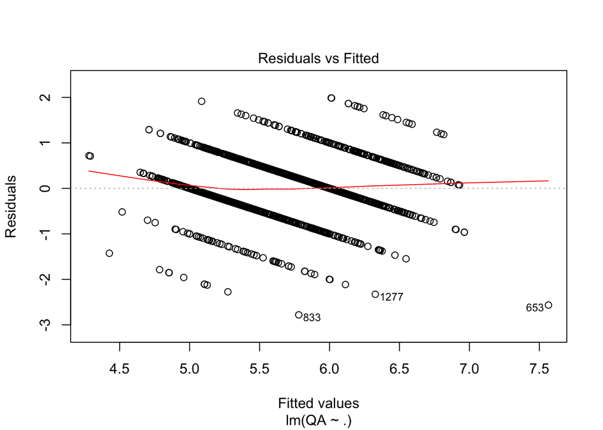

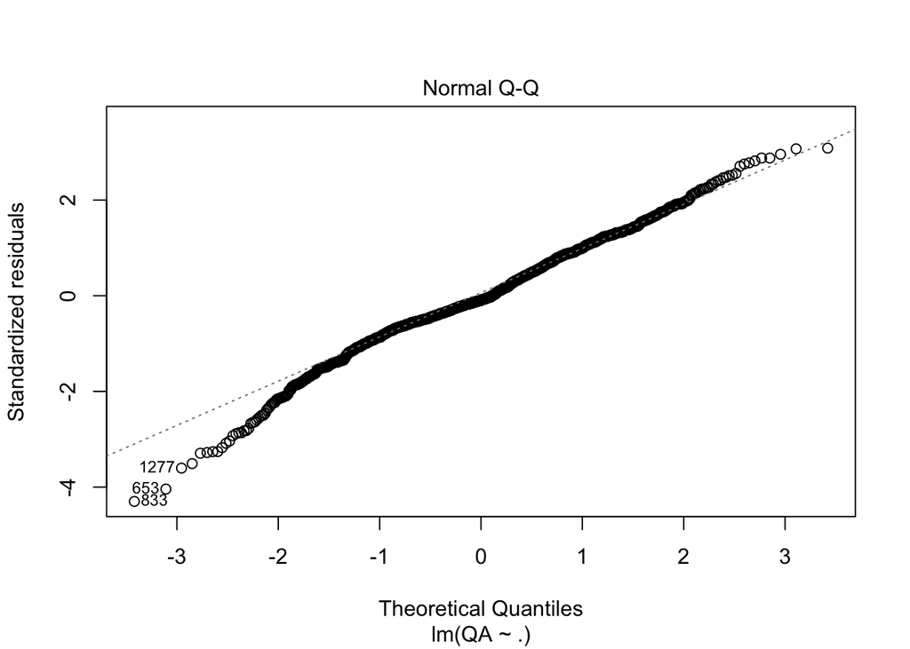

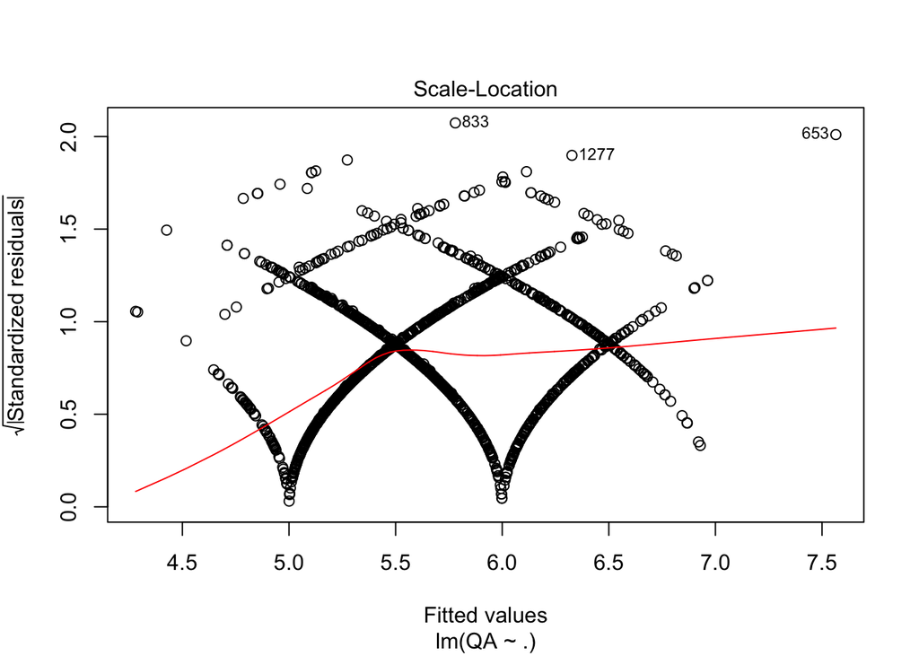

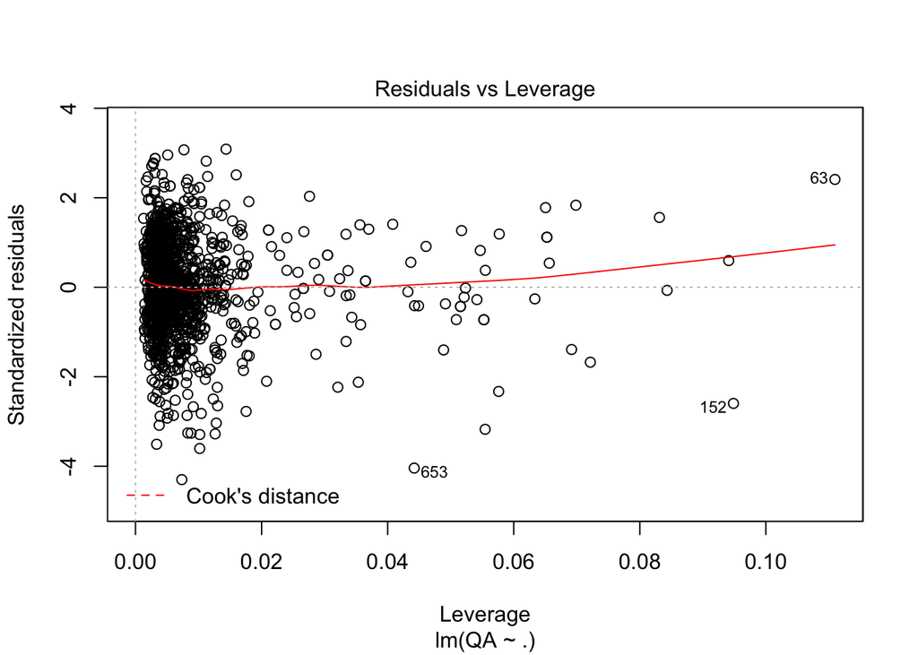

```r
# both r.squared are too low, but model 2 has higher r-squared,
# meaning it explains more variation in QA

# both have 4 insignificant attributes at 0.05 level
# model 1: CA, RS, FS, PH
# model 2: FA, CA, RS, DE

# both model have p-value < 2.2e-16 for the overall fit

# looking at residuals
plot(winemodel)
```

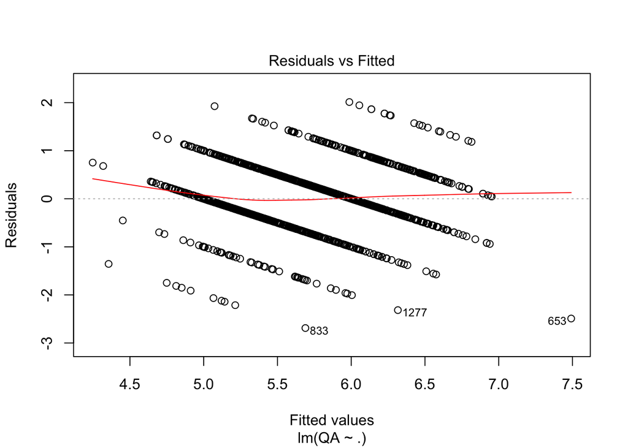

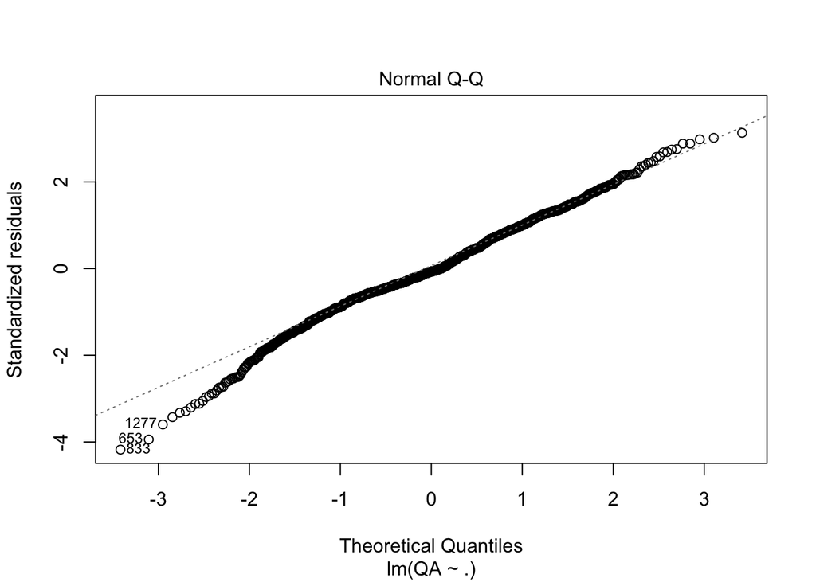

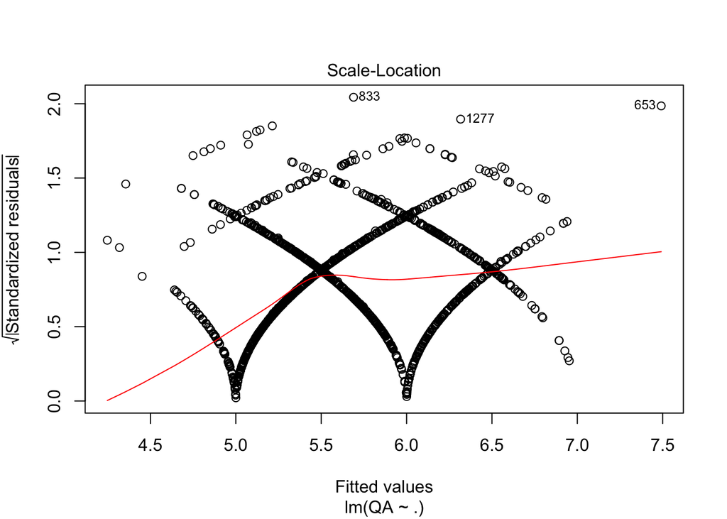

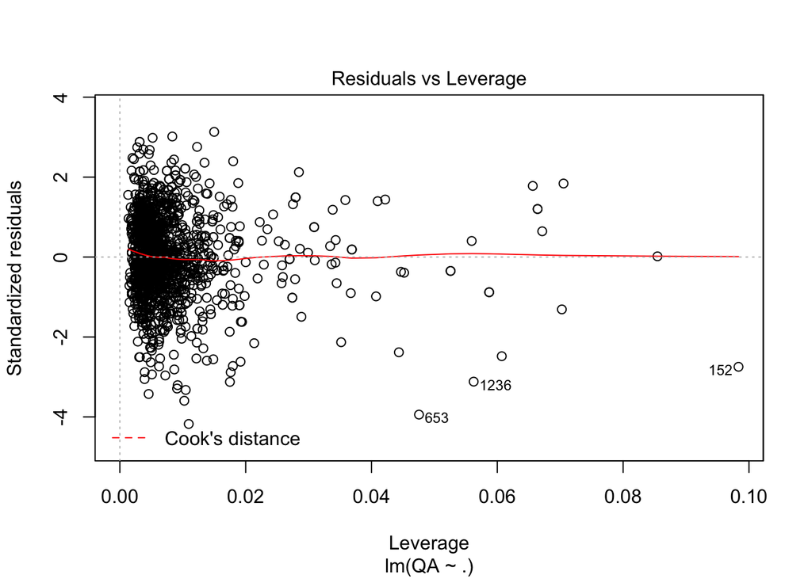

```r
plot(winemodel2)
```

```r
# leverage plot shows a higher influence of some data points in model 1

# from the above discussion, both models are not very good, but
# model 2 seems better than model 1.

# Pick 5 attributes that is most likely to be related to QA based on p-values
as.matrix(sort(summary(winemodel2)$coeff[-1,c("Pr(>|t|)")]))
```

```
##            [,1]
## AL 1.298628e-25
## VA 3.987768e-18
## SU 3.461990e-15
## CH 6.597172e-06
## SD 2.158380e-05
## PH 2.763384e-02
## FS 4.292722e-02
## CA 2.296053e-01
## FA 3.443096e-01
## RS 3.868817e-01
## DE 4.893255e-01
```

```r
# The attributes with 5 lowest p-values (most signficant effect on QA) are:
# AL, VA, SU, CH, SD
```